# Comparative Study of vcd::mosaic and geom_mosaic

By default, vcd::mosaic() splits horizontally from left for the first variable (e.g. ~ V1, ~ V1 + V2, ~ V2 | V1 or V2 ~ V1 – here V1 is considered as first variable) and vertically from top for the second variable and so on. If we want to alter this direction, we can provide this “direction” parameter. For example,

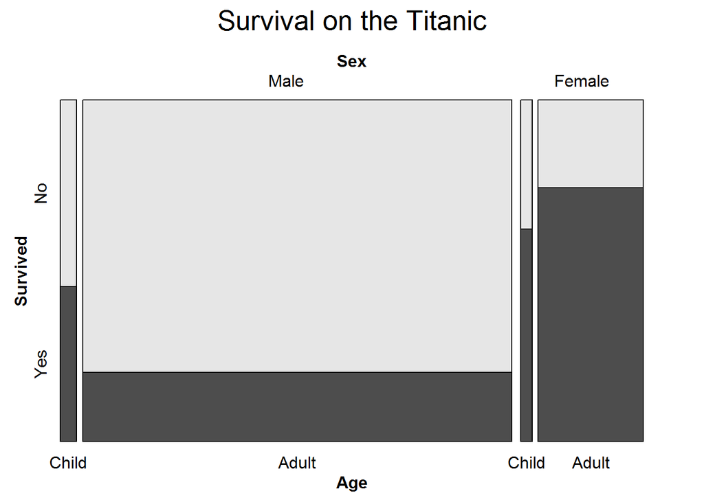

```r
 mosaic(Survived ~ Sex + Age, data = Titanic, main = "Survival on the Titanic",direction=c("v","v","h"))
```

# Sex = Vertical, Age = Vertical, Survived = Horizonal In the above plot, the sex variable is used to split the plot vertically, then age variable is used to sub-devide verticaly and then survived sub-division is highlighted horizontally from other side.

gp  
object of class “gpar”, shading function or a corresponding generating function (see details and shadings). Components of “gpar” objects are recycled as needed along the last splitting dimension. Ignored if shade = FALSE.

if gp is not provided, the default gray color is applied with shade = TRUE

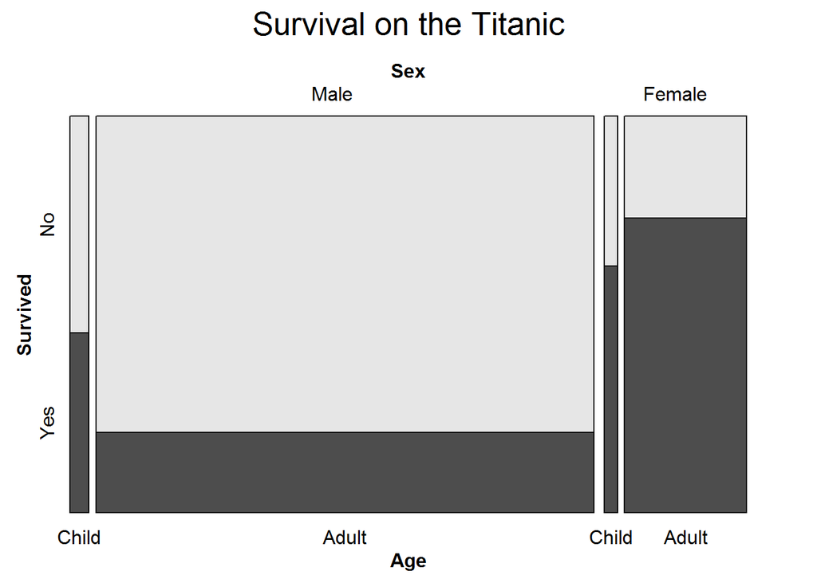

```r
mosaic(Survived~ Sex + Age, data = Titanic,
       main = "Survival on the Titanic", shade = TRUE,
       direction=c("v","v","h"))
```

if gp is provided with shade = TRUE (or no shade parameter but not shade = FALSE), the provided color along with other graphical paramters (if provided any) will apply.

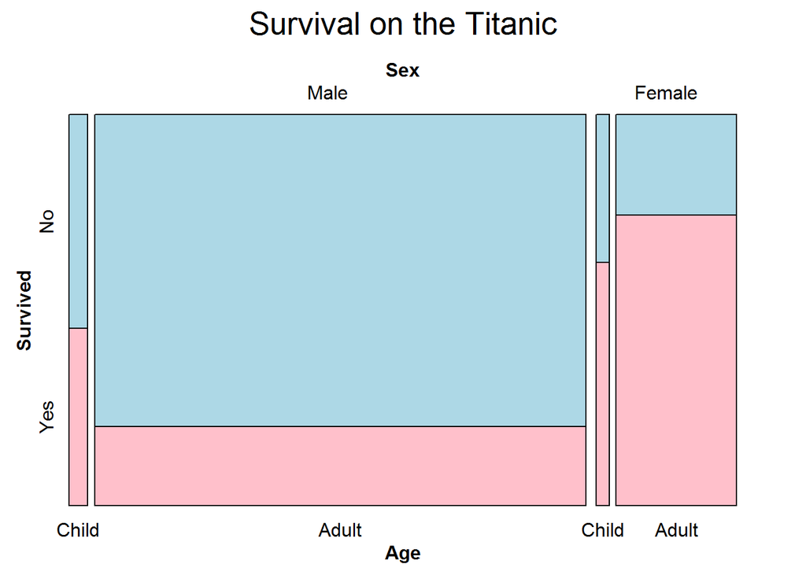

```r
mosaic(Survived~ Sex + Age, data = Titanic,
       main = "Survival on the Titanic", shade = TRUE,
       direction=c("v","v","h"), gp = gpar(fill=c('lightblue', 'pink'))
                 )
```

shade  
logical specifying whether gp should be used or not (see gp). If TRUE and expected is unspecified, a default model is fitted: if condvars (see strucplot) is specified, a corresponding conditional independence model, and else the total independence model.

If we provide shade = FALSe, the gp will not apply at all.

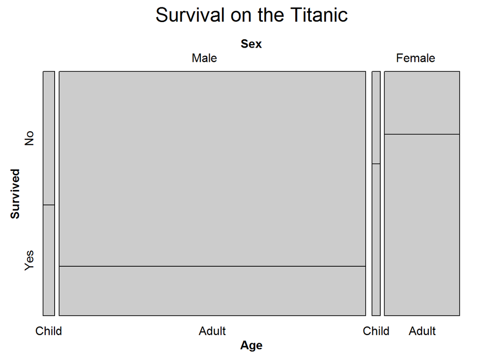

```r
mosaic(Survived~ Sex + Age, data = Titanic,
       main = "Survival on the Titanic", shade = FALSE,
       direction=c("v","v","h"), gp = gpar(fill=c('lightblue', 'pink'))
                 )
```

Reference: 1) https://pdfs.semanticscholar.org/2416/2c1a46669f94356854176ece8548bf7fb989.pdf 2) https://ncss-wpengine.netdna-ssl.com/wp-content/themes/ncss/pdf/Procedures/NCSS/Mosaic_Plots.pdf 3) https://en.wikipedia.org/wiki/Mosaic_plot 4) http://www.pmean.com/definitions/mosaic.htm